# HealthCareAndCauseOfDeath_Tableau

Herbert Gutierrez, Varun Parameswaran, Ryan Wechter

November 2, 2015

# Health Care and Causes of Death by State

#### This is Project 4 for Dr. Cannata’s Data Visualization class.

### Introduction

We have been working with these same two datasets (first is US healthcare expenditures over time, and second is US Causes of Death by State) for multiple R projects, so it was interesting to finally work with this data in Tableau. With the enhanced capability of Tableau, we wanted to drill down deeper into healthcare expenditures by item (hospital care, dental care, prescription drugs, etc.) and correlate these figures with deaths.

#### Dataset 1: National Healthcare Expenditures

```r
setwd("~/DataVisualization/DV_TProject1/01 Data")

file_path <- "US_AGGREGATE09.CSV.reformatted.csv"

df1 <- read.csv(file_path, stringsAsFactors = FALSE)

head(df1)
```

```
##   Code                                       Item         Group
## 1    1 Personal Health Care (Millions of Dollars) United States
## 2    1 Personal Health Care (Millions of Dollars)        Region
## 3    1 Personal Health Care (Millions of Dollars)         State
## 4    1 Personal Health Care (Millions of Dollars)         State
## 5    1 Personal Health Care (Millions of Dollars)         State
## 6    1 Personal Health Care (Millions of Dollars)         State
##   Region_Number   Region_Name    State_Name      Y1980      Y1981
## 1             0 United States               217102.314 251922.637
## 2             1   New England                12867.505  14745.225
## 3             1   New England   Connecticut   3142.373   3626.125
## 4             1   New England         Maine    950.805   1087.758
## 5             1   New England Massachusetts   6724.031   7665.162
## 6             1   New England New Hampshire    685.510    812.446
##        Y1982      Y1983      Y1984      Y1985      Y1986      Y1987
```

[output cut: 41 more lines]

```r
summary(df1)
```

```
##       Code        Item              Group           Region_Number
##  Min.   : 1   Length:660         Length:660         Min.   :0.00
##  1st Qu.: 3   Class :character   Class :character   1st Qu.:2.75
##  Median : 6   Mode  :character   Mode  :character   Median :5.00
##  Mean   : 6                                         Mean   :4.40
##  3rd Qu.: 9                                         3rd Qu.:6.00
##  Max.   :11                                         Max.   :8.00
##  Region_Name         State_Name            Y1980
##  Length:660         Length:660         Min.   :     0.97
##  Class :character   Class :character   1st Qu.:    54.67
##  Mode  :character   Mode  :character   Median :   205.41
##                                        Mean   :  1973.66
##                                        3rd Qu.:   859.98
##                                        Max.   :217102.31
##      Y1981               Y1982               Y1983
##  Min.   :     0.67   Min.   :     0.75   Min.   :     1.05
##  1st Qu.:    63.87   1st Qu.:    72.44   1st Qu.:    81.09
##  Median :   236.86   Median :   269.98   Median :   306.09
##  Mean   :  2290.21   Mean   :  2574.82   Mean   :  2834.90
##  3rd Qu.:  1023.74   3rd Qu.:  1141.94   3rd Qu.:  1262.27
##  Max.   :251922.64   Max.   :283230.29   Max.   :311839.01
##      Y1984              Y1985              Y1986
##  Min.   :     1.3   Min.   :     1.5   Min.   :     2.5
##  1st Qu.:    93.4   1st Qu.:   106.8   1st Qu.:   117.1
##  Median :   346.4   Median :   373.4   Median :   419.9
##  Mean   :  3108.3   Mean   :  3425.1   Mean   :  3721.5
##  3rd Qu.:  1396.7   3rd Qu.:  1549.5   3rd Qu.:  1716.3
##  Max.   :341912.0   Max.   :376758.1   Max.   :409365.6
##      Y1987              Y1988              Y1989
##  Min.   :     2.5   Min.   :     2.7   Min.   :     2.7
##  1st Qu.:   129.5   1st Qu.:   145.1   1st Qu.:   156.9
##  Median :   467.3   Median :   532.1   Median :   579.2
##  Mean   :  4075.7   Mean   :  4539.2   Mean   :  5012.8
##  3rd Qu.:  1930.5   3rd Qu.:  2173.7   3rd Qu.:  2377.1
##  Max.   :448330.3   Max.   :499314.4   Max.   :551406.8
##      Y1990              Y1991              Y1992
##  Min.   :     2.8   Min.   :     3.3   Min.   :     4.8
##  1st Qu.:   185.3   1st Qu.:   198.9   1st Qu.:   212.4
##  Median :   643.7   Median :   688.3   Median :   740.3
##  Mean   :  5605.4   Mean   :  6158.2   Mean   :  6667.7
```

[output cut: 29 more lines]

```
##  Max.   :1371616.8   Max.   :1478984.7   Max.   :1585019.8
##      Y2005               Y2006               Y2007
##  Min.   :     27.4   Min.   :     31.4   Min.   :     30.0
##  1st Qu.:    582.0   1st Qu.:    606.0   1st Qu.:    641.8
##  Median :   1883.6   Median :   1987.7   Median :   2137.6
##  Mean   :  15387.2   Mean   :  16352.9   Mean   :  17312.2
##  3rd Qu.:   7839.3   3rd Qu.:   8287.0   3rd Qu.:   8663.5
##  Max.   :1692591.2   Max.   :1798822.2   Max.   :1904344.1
##      Y2008               Y2009           Average_Annual_Percent_Growth
##  Min.   :     31.9   Min.   :     39.6   Min.   : 1.600
##  1st Qu.:    680.5   1st Qu.:    692.3   1st Qu.: 7.300
##  Median :   2291.3   Median :   2398.0   Median : 8.500
##  Mean   :  18156.4   Mean   :  18998.7   Mean   : 8.831
##  3rd Qu.:   9103.4   3rd Qu.:   9524.3   3rd Qu.:10.500
##  Max.   :1997199.3   Max.   :2089862.3   Max.   :19.700
```

#### Dataset 2: Cause of Death

```r
setwd("~/DataVisualization/DV_TProject1/01 Data")

file_path <- "LeadingCausesStateYear.csv"

df2 <- read.csv(file_path, stringsAsFactors = FALSE)

head(df2)
```

```
##   YEAR                                      X113_CAUSE_NAME
## 1 1999 Accidents (unintentional injuries) (V01-X59,Y85-Y86)
## 2 1999 Accidents (unintentional injuries) (V01-X59,Y85-Y86)
## 3 1999 Accidents (unintentional injuries) (V01-X59,Y85-Y86)
## 4 1999 Accidents (unintentional injuries) (V01-X59,Y85-Y86)
## 5 1999 Accidents (unintentional injuries) (V01-X59,Y85-Y86)
## 6 1999 Accidents (unintentional injuries) (V01-X59,Y85-Y86)
##               CAUSE_NAME      STATE DEATHS  AADR
## 1 Unintentional Injuries    Alabama   2313 52.17
## 2 Unintentional Injuries     Alaska    294 55.91
## 3 Unintentional Injuries    Arizona   2214 44.79
## 4 Unintentional Injuries   Arkansas   1287 47.56
## 5 Unintentional Injuries California   9198 28.71
## 6 Unintentional Injuries   Colorado   1519 38.98
```

```r
summary(df2)
```

```
##       YEAR      X113_CAUSE_NAME     CAUSE_NAME           STATE
##  Min.   :1999   Length:13260       Length:13260       Length:13260
##  1st Qu.:2002   Class :character   Class :character   Class :character
##  Median :2006   Mode  :character   Mode  :character   Mode  :character
##  Mean   :2006
##  3rd Qu.:2010
##  Max.   :2013
##     DEATHS              AADR
##  Length:13260       Length:13260
##  Class :character   Class :character
##  Mode  :character   Mode  :character
##
##
##
```

### Visualization #1: Crosstab

This crosstab has states for its rows and healthcare expenditure items for its columns. The KPI inside the crosstab is the average annual percentage growth in expenditures, year over year from 1980 - 2009. The growth rates are separated as High (KPI > 10%), Medium (7% < KPI < 10%), and Low (KPI < 7%) according to our Tableau parameters.

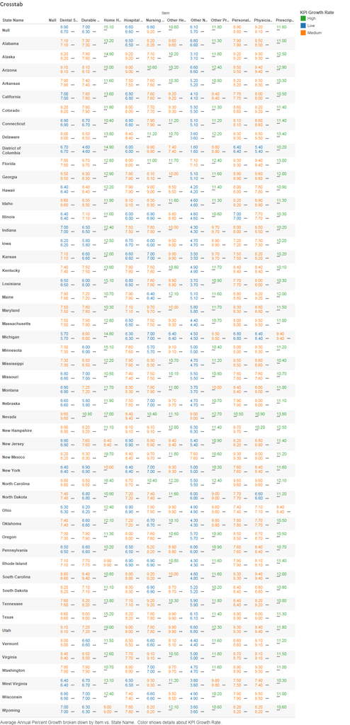

From this crosstab, we easily see that the expenditure items with the fastest-growing expenditures are Home Health Care; Other Health, Residential, and Personal Care; Other Professional Services; and Prescription Drugs. As the next graph (Visualization 2: Bar Chart) shows, it’s possible that these items’ growth rates are exaggerated because they started off as such negligibly low numbers.

The expenditure items with the slowest-growing expenditures are Dental Services, Durable Medical Products, and Other Non-Durable Medical Products. We believe that expenditures on dental services and medical products have not increased as rapidly because they are less closely tied to rising health insurance costs, which are generally blamed for rising healthcare costs.

The states with the fastest-growing expenditures are Arizona, Delaware, Florida, Nevada, and North Carolina. The states with the slowest-growing expenditures are New York, Michigan, Illinois, Iowa, and the District of Columbia. We found little correlation between states here to suggest any concentration based on regional or political characteristics.

### Visualization 2: Bar Chart

This bar chart has Expenditures in millions for its y-axis and Years for its x-axis. The bars are broken down by item, and all data has been filtered to only include the state of Texas.

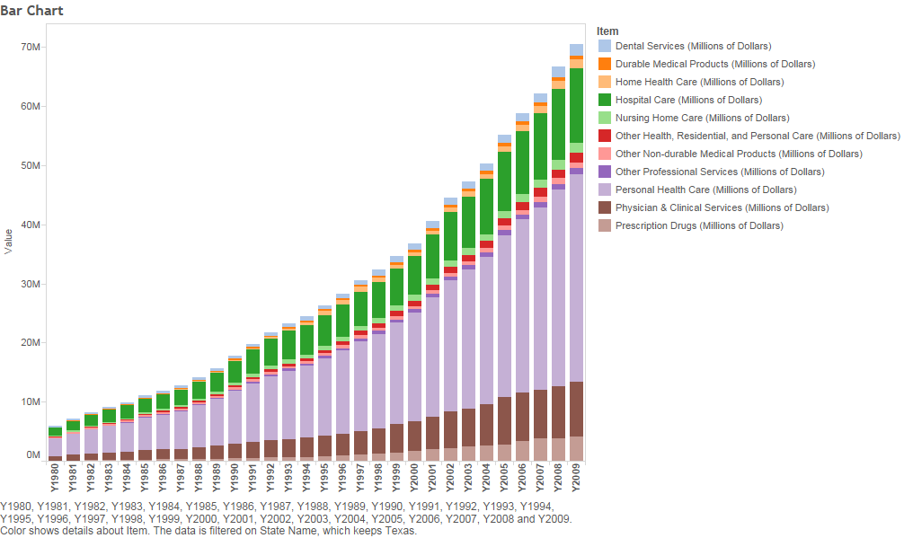

This chart perfectly captures the rising costs of healthcare in Texas, and more broadly, the United States (we can infer this because of the previous crosstab; Texas’s annual percentage growth numbers are very similar to those of the other states, so their expenditures can be expected to have grown at a similar rate). The cost rise is fairly uniform across items. In other words, the relative composition by item of each of the bars remains relatively the same from 1980-2009. Therefore, we conclude that, with a few exceptions, US healthcare costs rose uniformly by item from 1980-2009. If anything, the overall rate of growth accelerated in the 2000s. For future consideration and if data is available, it would be interesting to see how this trend has changed with the institution of Obamacare.

### Visualization 3: Scatterplot

This scatterplot has Hospital Care expenditures (represented here as Y1999) for the y-axis and number of deaths for the x-axis. The data points represent each of the 50 states, plus the null value for US territories. We filtered to reduce the scope and improve the graph’s readability by only showing data from the year 1999 and causes of death related to heart disease.

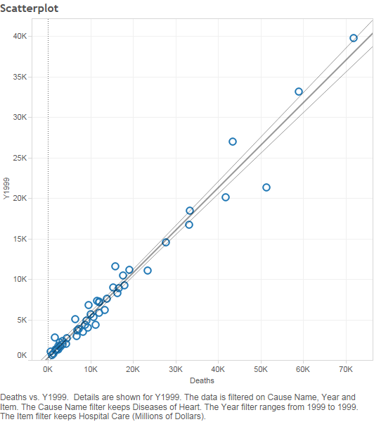